# Assignment 8 - Jonas Gstoetenmayr

## Exercise 1 LangChain Multi-Step Chains: Research Paper Analysis Pipeline

Complex tasks can often be decomposed into multiple smaller reasoning steps. In this exercise, you will use LangChain to construct a multi-step pipeline that analyzes a scientific research paper and produces management-ready output. The goal is to transform a technical PDF into an executive summary and actionable recommendations.

**Tasks:**

1. Find a paper that about at topic that is relevant. -> [(https://link.springer.com/article/10.1007/s40593-021-00270-2)](https://link.springer.com/article/10.1007/s40593-021-00270-2)
2. Load and process the research paper in PDF format.
3. Build a multi-step LangChain pipeline that:
   - extracts the main research question and methodology,
   - identifies key findings,
   - generates a non-technical executive summary,
   - derives concrete action items and potential risks.
4. Ensure that each step of the pipeline produces an explicit intermediate output.
5. Reflect on the benefits of chaining multiple steps compared to using a single, large prompt.

**Deliverables:** A notebook containing the multi-step chain, intermediate outputs, and final executive summary with action items.

**Answer** Reflection:

- Saving intermediate steps, each step is a smaller task and thus faster than the whole, so we can save intermediate results in case of failure
- easier debugging, by seeing the intermediate results we can find out far easer where the problem lies
- parrallelisation is possible with tasks that can run in parallel, allowing for large speedups (if we have the hardware)
- For prompts with large inputs/outputs, we have smaller context lengths allowing for usage of more models (or making impossible prompts more possilbe)
- it is a way to subvert the bias towards the beginning and end, by first summarizing documents the LLM has less tokens to process and can focus better on qualities it extracted
- allows for reusing intermediate results for multiple purposes (less LLM calls)

```python
from langgraph.graph import StateGraph, START, END
from langchain.messages import SystemMessage
from typing_extensions import TypedDict
from IPython.display import Image, display
from langchain_ollama import ChatOllama
```

### PDF reading + processing

```python
from pypdf import PdfReader

def read_pdf(file_path: str):
    paper = ""

    reader = PdfReader(file_path)
    # print(len(reader.pages))
    for page in reader.pages[7:15]: # quick overview seems to be best
        paper += page.extract_text()

    abstract = reader.pages[0].extract_text()
    return abstract, paper
abstract, paper = read_pdf("./research_paper.pdf")
print(paper[-300:])
```

```
37
devote more attention.
Bringing AIED Ethics into Policy
In light of these findings, why is ethics an appropriate lens through which to
approach AIED policy, as this article contends? How should AIED ethics and
AIED policy ultimately be related? Foremost as I have argued, ethics and policy are
541
```

```python
def process_pdf(paper: str):
    new_paper = []
    skip = False
    for line in paper.split("\n"):
        if skip:
            skip = False
            continue
        if "InternationalJournalofArtiﬁcialIntelligenceinEducation" in line:
            skip = True
            continue
        new_paper.append(line)
    return "\n".join(new_paper[:-1])
print(process_pdf(paper)[:300])
```

```
are not coded at a fine level of detail and are fairly easy to conceptually separate.
Nevertheless, the analysis is necessarily subjective.
Analysis Topics
The codebook development process resulted in five primary topics and two addi -
tional coding categories. The five primary topics are divided i
```

```python
print(abstract[:300])
```

```
InternationalJournalofArtiﬁcialIntelligenceinEducation (2022)32:527–563
Vol.:(0123456789)
https://doi.org/10.1007/s40593-021-00270-2
1 3
ARTICLE
Education for AI, not AI for Education: The Role of Education
and Ethics in National AI Policy Strategies
Daniel Schiff1
Accepted: 26 July 2021
© Intern
```

### Pipeline

```python
llm = ChatOllama(
    model="ministral-3:14b",
    temperature=0.0,
    streaming=False,
    verbose=True,
    # num_predict=1024
)
```

```python
systemprompt_starter = ("You will answer concisely."
                        "Do not acknowledge the user prompt."
                        "Do not provide a step-by-step explanation or internal reasoning."
                        " Provide the final answer immediately.")
```

```python
class State(TypedDict):
    pdf_path: str
    abstract: str
    paper: str
    topic: str
    key_findings: str
    non_technical_summary: str
    decisions_and_risks: str
```

```python
def print_topic(topic: str, state: State):
    print(f"{'='*25} {topic} {'='*25}")
    print(state[topic])
    print(f"{'-'*25} {'-'*len(topic)} {'-'*25}")
```

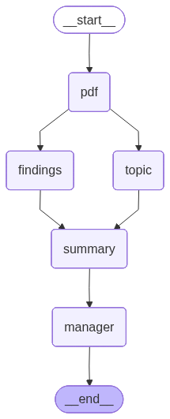

```python
# modeled after https://docs.langchain.com/oss/python/langgraph/workflows-agents#prompt-chaining

def get_paper(state: State):
    abstract, paper = read_pdf(state["pdf_path"])
    abstract = process_pdf(abstract)
    paper = process_pdf(paper)
    return {"abstract": abstract, "paper": paper}


def ask_llm_print_answer(state: State, system_prompt: str, step: str):
    answer = llm.invoke(
            [SystemMessage(content= systemprompt_starter + system_prompt)]
            )
    print(f"{'='*25} Step: {step} {'='*25}")
    print("LLM answer: ", answer.content)
    print()
    return {step: answer.content}

def topic_extraction(state: State):
    """"Invoke the LLM for topic instructions"""
    return ask_llm_print_answer(state,
                                f"You are a professional researcher. Your job is to extract the main research question and methodology of the paper provided to you. Paper: {state['abstract']}",
                                "topic")

def key_findings_extraction(state: State):
    """"Invoke the for key findings"""
    return ask_llm_print_answer(state,
                                f"You are a professional summarizer. Your job is to extract the key findings of the paper provided to you. Extract them into a list of bullet points. Paper: {state['paper']}",
                                "key_findings")

def non_technical_summary(state: State):
    """"Invoke the for key findings"""
    return ask_llm_print_answer(state,
                                f"You are a professional presenter. Your job is to take you partners summary and make it non-technical and presentible to management. Topic: {state['topic']}\n Key topics: {state['key_findings']}",
                                "non_technical_summary")

def manager_decision(state: State):
    """"Invoke the for key findings"""
    return ask_llm_print_answer(state,
                                f"You are a professional manager. Your job to take your employees summary and derive concrete actions and risks from it. Summary: {state['non_technical_summary']}",
                                "decisions_and_risks")


graph = StateGraph(State)
graph.add_node("pdf", get_paper)
graph.add_node("topic", topic_extraction)
graph.add_node("findings", key_findings_extraction)
graph.add_node("summary", non_technical_summary)
graph.add_node("manager", manager_decision)

graph.add_edge(START, "pdf")
graph.add_edge("pdf", "topic")
graph.add_edge("pdf", "findings")
graph.add_edge("topic", "summary")
graph.add_edge("findings", "summary")
graph.add_edge("summary", "manager")
graph.add_edge("manager", END)

chain = graph.compile()

display(Image(chain.get_graph().draw_mermaid_png()))
```

```python
state = chain.invoke({"pdf_path": "/home/azureuser/localfiles/jonas_g/NLP4/EX08/research_paper.pdf"})
```

```
37
========================= Step: topic =========================
LLM answer:  **Research Question:**
How do national AI policy strategies address the role of education, particularly the ethical implications of AI in education (AIED), and what gaps exist in current policy discourse regarding AIED?

**Methodology:**
Thematic analysis of 24 national AI policy strategies, focusing on the representation of education and ethical considerations in AIED.

========================= Step: key_findings =========================
LLM answer:  intertwined in the context of AIED. Here’s a structured breakdown of why ethics should be central to AIED policy and how they should be integrated:

---

### **1. Why Ethics is Central to AIED Policy**
#### **A. Transformative Potential of AIED**
   - **Educational Revolution**: AIED has the potential to fundamentally alter how education is delivered, assessed, and experienced. This includes personalized learning, adaptive curricula, and immersive environments (e.g., VR/AR). Such transformations raise profound ethical questions about equity,…
   - **Example**: Spain’s AI policy strategy acknowledges that AIED could "completely transform current education," but this transformation must be guided by ethical considerations to avoid exacerbating existing inequalities or creating new forms of exclusion.

#### **B. Ethical Risks Unique to AIED**
   AIED introduces ethical dilemmas that are distinct from other AI applications:
   - **Bias and Discrimination**: AI systems trained on biased data can perpetuate or amplify existing disparities in education. For example, if an AI grading system is trained predominantly on data from privileged backgrounds, it may unfairly penalize students from underrepresented groups.
   - **Privacy Concerns**: AIED often requires extensive data collection on students (e.g., learning patterns, behavioral data). This raises questions about consent, data ownership, and the potential for misuse (e.g., profiling, surveillance).
   - **Transparency and Accountability**: AI systems in education must be explainable to stakeholders (students, teachers, parents) to ensure trust and accountability. Black-box models could lead to distrust or resistance.
   - **Autonomy and Agency**: Students and teachers must retain agency over their learning and teaching processes. Over-reliance on AI could undermine human judgment and creativity.
   - **Digital Divide**: AIED risks exacerbating inequalities if access to technology is uneven. Low-income students or regions with poor infrastructure may be left behind.
   - **Long-Term Impact on Learning**: The use of AI in education could shape cognitive development, social skills, and even identity formation. For example, over-personalization might limit exposure to diverse perspectives.

#### **C. Policy Gaps and Ethical Blind Spots**
   - **Lack of Ethical Frameworks**: Most national AI policies (as discussed) focus on economic competitiveness and workforce development but overlook the ethical dimensions of AIED. This creates a policy vacuum where ethical risks go unaddressed.
   - **Short-Term vs. Long-Term Thinking**: Policymakers often prioritize immediate economic or technological gains (e.g., STEM workforce) over long-term ethical and societal impacts of AIED.
   - **Marginalization of Stakeholders**: Teachers, students, and parents are rarely consulted in AIED policy discussions, leading to solutions that may not align with their needs or values.

#### **D. Alignment with Broader Ethical Debates in AI**
   AIED ethics must be considered within the broader ethical debates surrounding AI, such as:
   - **Fairness and Justice**: How can AIED ensure equitable outcomes for all students?
   - **Human Rights**: Does AIED respect students' rights to privacy, autonomy, and non-discrimination?
   - **Sustainability**: How can AIED be designed to support sustainable and inclusive education systems?
   - **Global Equity**: How can AIED address the needs of developing countries, where educational infrastructure is often limited?

---
```

[output cut: 102 more lines]

```
8. **Monitor & Enforce Compliance** – Implement real-time monitoring of AI tools for bias, privacy breaches, and ethical violations, with corrective actions for violations.
9. **Allocate Budget for Ethical AI Research** – Fund internal and external research on AI ethics in education to stay ahead of emerging risks.
10. **Advocate for Policy Changes** – Lobby governments and industry bodies to adopt ethical AIED standards, emphasizing long-term trust and equity over short-term gains.

**Key Risks:**
- **Bias & Discrimination** – AI tools may reinforce or amplify existing inequalities if not audited for fairness.
- **Privacy Violations** – Unregulated data collection could lead to student surveillance or misuse of personal data.
- **Loss of Trust** – Poorly implemented AI could erode trust in educational institutions and technology.
- **Digital Divide** – Unequal access to AI tools may widen achievement gaps between privileged and underrepresented groups.
- **Autonomy Erosion** – Over-reliance on AI could reduce teacher-student interaction and limit student agency.
- **Regulatory Gaps** – Lack of global standards may lead to inconsistent protections and exploitation of loopholes.
- **Ethical Blind Spots** – Without stakeholder input, policies may overlook critical ethical concerns in real-world applications.
- **Financial & Reputational Costs** – Ethical failures could result in lawsuits, regulatory fines, and long-term reputational damage.
- **Stifled Innovation** – Overly restrictive policies might discourage beneficial AI advancements if not balanced with flexibility.
- **Global Inequity** – Developing nations may adopt AIED without safeguards, exacerbating global educational disparities.
```

```python
state.keys()
```

```
dict_keys(['pdf_path', 'abstract', 'paper', 'topic', 'key_findings', 'non_technical_summary', 'decisions_and_risks'])
```

```python
print_topic("topic", state)#type:ignore
```

```
========================= topic =========================
**Research Question:**
How do national AI policy strategies address the role of education, particularly the ethical implications of AI in education (AIED), and what gaps exist in current policy discourse regarding AIED?

**Methodology:**
Thematic analysis of 24 national AI policy strategies, focusing on the representation of education and ethical considerations in AIED.
------------------------- ----- -------------------------
```

```python
print_topic("key_findings", state)#type:ignore
```

```
========================= key_findings =========================
intertwined in the context of AIED. Here’s a structured breakdown of why ethics should be central to AIED policy and how they should be integrated:

---

### **1. Why Ethics is Central to AIED Policy**
#### **A. Transformative Potential of AIED**
   - **Educational Revolution**: AIED has the potential to fundamentally alter how education is delivered, assessed, and experienced. This includes personalized learning, adaptive curricula, and immersive environments (e.g., VR/AR). Such transformations raise profound ethical questions about equity,…
   - **Example**: Spain’s AI policy strategy acknowledges that AIED could "completely transform current education," but this transformation must be guided by ethical considerations to avoid exacerbating existing inequalities or creating new forms of exclusion.

#### **B. Ethical Risks Unique to AIED**
   AIED introduces ethical dilemmas that are distinct from other AI applications:
   - **Bias and Discrimination**: AI systems trained on biased data can perpetuate or amplify existing disparities in education. For example, if an AI grading system is trained predominantly on data from privileged backgrounds, it may unfairly penalize students from underrepresented groups.
   - **Privacy Concerns**: AIED often requires extensive data collection on students (e.g., learning patterns, behavioral data). This raises questions about consent, data ownership, and the potential for misuse (e.g., profiling, surveillance).
   - **Transparency and Accountability**: AI systems in education must be explainable to stakeholders (students, teachers, parents) to ensure trust and accountability. Black-box models could lead to distrust or resistance.
   - **Autonomy and Agency**: Students and teachers must retain agency over their learning and teaching processes. Over-reliance on AI could undermine human judgment and creativity.
   - **Digital Divide**: AIED risks exacerbating inequalities if access to technology is uneven. Low-income students or regions with poor infrastructure may be left behind.
   - **Long-Term Impact on Learning**: The use of AI in education could shape cognitive development, social skills, and even identity formation. For example, over-personalization might limit exposure to diverse perspectives.

#### **C. Policy Gaps and Ethical Blind Spots**
   - **Lack of Ethical Frameworks**: Most national AI policies (as discussed) focus on economic competitiveness and workforce development but overlook the ethical dimensions of AIED. This creates a policy vacuum where ethical risks go unaddressed.
   - **Short-Term vs. Long-Term Thinking**: Policymakers often prioritize immediate economic or technological gains (e.g., STEM workforce) over long-term ethical and societal impacts of AIED.
   - **Marginalization of Stakeholders**: Teachers, students, and parents are rarely consulted in AIED policy discussions, leading to solutions that may not align with their needs or values.

#### **D. Alignment with Broader Ethical Debates in AI**
   AIED ethics must be considered within the broader ethical debates surrounding AI, such as:
   - **Fairness and Justice**: How can AIED ensure equitable outcomes for all students?
   - **Human Rights**: Does AIED respect students' rights to privacy, autonomy, and non-discrimination?
   - **Sustainability**: How can AIED be designed to support sustainable and inclusive education systems?
   - **Global Equity**: How can AIED address the needs of developing countries, where educational infrastructure is often limited?

---

### **2. How to Integrate Ethics into AIED Policy**
To ensure that AIED policies are ethical, proactive, and inclusive, the following steps should be taken:

#### **A. Develop Ethical Frameworks for AIED**
   - **Principle-Based Approaches**: Adopt ethical principles tailored to AIED, such as:
     - **Equity**: Ensure AIED systems do not reinforce or create new inequalities.
     - **Transparency**: AIED systems should be explainable and their decision-making processes understandable to all stakeholders.
```

[output cut: 54 more lines]

```
   - **India’s Predictive Tools**: India’s proposal to use AI for predicting student dropout risks is innovative but raises ethical questions about the accuracy of predictions and the potential for stigmatizing students labeled as "at risk."

---

### **5. Challenges and Considerations**
   - **Balancing Innovation and Ethics**: Policymakers must avoid stifling innovation while ensuring that ethical risks are mitigated. This requires a delicate balance between regulation and flexibility.
   - **Global vs. Local Contexts**: Ethical standards may vary across cultures and contexts. Policies must be adaptable to local needs while upholding universal ethical principles.
   - **Resistance to Change**: Teachers and institutions may resist AIED due to concerns about job displacement or loss of control. Policymakers must address these fears through training and inclusive dialogue.
   - **Long-Term Commitment**: Ethical AIED requires sustained investment in research, education, and governance, which may be challenging in resource-constrained environments.

---

### **6. Conclusion**
Ethics must be the cornerstone of AIED policy to ensure that technological advancements in education are equitable, transparent, and beneficial for all. By integrating ethical frameworks, engaging stakeholders, and establishing robust governance mechanisms, policymakers can harness the potential of …
------------------------- ------------ -------------------------
```

```python
print_topic("non_technical_summary", state)#type:ignore
```

```
========================= non_technical_summary =========================
**Key Takeaway for Management:**

National AI policies often overlook the ethical risks of AI in education, despite its transformative potential. **AI in education (AIED) raises critical ethical concerns**—like bias, privacy, and unequal access—that current policies fail to address adequately.

**The Gap:** Most strategies focus on economic benefits (e.g., workforce readiness) but ignore how AI could deepen inequalities, erode trust, or limit student agency. For example, AI grading systems might unfairly penalize underrepresented groups, or data collection could violate student privacy wit…

**What’s Needed:**
1. **Ethical Guardrails:** Policies must embed principles like fairness, transparency, and inclusivity into AIED tools—similar to how the EU’s AI Ethics Guidelines work for broader AI applications.
2. **Stakeholder Involvement:** Teachers, students, and parents should shape AIED policies, not just tech companies or governments. Pilot programs with ethical reviews can test risks before widespread adoption.
3. **Global Standards:** Collaboration with organizations like UNESCO can help create consistent ethical benchmarks, especially for developing nations where AIED could exacerbate digital divides.
4. **Education & Accountability:** Train educators on ethical AI use, mandate bias audits for AI tools, and establish independent ethics boards to oversee compliance.

**Why It Matters:** Without ethical leadership, AI in education could widen gaps, undermine trust, and prioritize efficiency over human values. **Proactive policies today can prevent costly mistakes tomorrow.** Investing in ethical AIED isn’t a barrier—it’s the foundation for responsible innovation.
------------------------- --------------------- -------------------------
```

```python
print_topic("decisions_and_risks", state)#type:ignore
```

```
========================= decisions_and_risks =========================
**Concrete Actions:**

1. **Implement Ethical AI Frameworks** – Adopt and enforce EU-style AI ethics guidelines tailored for education, mandating fairness, transparency, and privacy audits for all AI tools.
2. **Establish Cross-Functional Ethics Boards** – Create independent boards with educators, students, and ethicists to review AI implementations and enforce compliance.
3. **Launch Pilot Programs with Ethical Safeguards** – Test AI tools in controlled environments with bias audits, stakeholder feedback, and privacy protections before scaling.
4. **Develop Global Ethical Standards** – Partner with UNESCO to co-develop universal AIED ethics benchmarks, prioritizing equity and accessibility.
5. **Mandate Bias & Privacy Audits** – Require third-party audits for all AI tools before procurement, with penalties for non-compliance.
6. **Train Educators & Staff** – Conduct mandatory workshops on ethical AI use, focusing on bias recognition, data privacy, and student agency.
7. **Engage Stakeholders in Policy Design** – Form councils with teachers, students, parents, and civil society to co-create AIED policies and governance models.
8. **Monitor & Enforce Compliance** – Implement real-time monitoring of AI tools for bias, privacy breaches, and ethical violations, with corrective actions for violations.
9. **Allocate Budget for Ethical AI Research** – Fund internal and external research on AI ethics in education to stay ahead of emerging risks.
10. **Advocate for Policy Changes** – Lobby governments and industry bodies to adopt ethical AIED standards, emphasizing long-term trust and equity over short-term gains.

**Key Risks:**
- **Bias & Discrimination** – AI tools may reinforce or amplify existing inequalities if not audited for fairness.
- **Privacy Violations** – Unregulated data collection could lead to student surveillance or misuse of personal data.
- **Loss of Trust** – Poorly implemented AI could erode trust in educational institutions and technology.
- **Digital Divide** – Unequal access to AI tools may widen achievement gaps between privileged and underrepresented groups.
- **Autonomy Erosion** – Over-reliance on AI could reduce teacher-student interaction and limit student agency.
- **Regulatory Gaps** – Lack of global standards may lead to inconsistent protections and exploitation of loopholes.
- **Ethical Blind Spots** – Without stakeholder input, policies may overlook critical ethical concerns in real-world applications.
- **Financial & Reputational Costs** – Ethical failures could result in lawsuits, regulatory fines, and long-term reputational damage.
- **Stifled Innovation** – Overly restrictive policies might discourage beneficial AI advancements if not balanced with flexibility.
- **Global Inequity** – Developing nations may adopt AIED without safeguards, exacerbating global educational disparities.
------------------------- ------------------- -------------------------
```

## Exercise 2 LangChain Agents & MCP Tooling: AI Project Manager Agent

LangChain agents can autonomously decide which tools to use in order to achieve a goal. In this exercise, you will build an AI project manager agent that interacts with an existing MCP server for creating, editing, and querying tickets. The agent should support basic project coordination tasks such as breaking down goals into tickets and updating their status.

**Tasks:**

1. Finalize MCP ticket server (if not already done in the exercise) to provide creating, editing, and querying tickets.
2. Integrate the MCP ticket server as a tool usable by a LangChain agent.
3. Define clear tool descriptions so the agent can decide when and how to use them.
4. Implement an agent that:
   - accepts a high-level project goal,
   - creates and updates tickets using the MCP server,
   - queries existing tickets to track progress.
5. Log and analyze the agent's tool usage and decision-making behavior.

**Deliverables:** A notebook demonstrating the agent, example project goals, generated tickets, and a brief analysis of agent behavior.

The Mcp server (It automatically filters out the Args and Return values in the docstring, so the annotated fields are a must :C)

```
from fastmcp import FastMCP
from datetime import datetime
from typing import Annotated
from pydantic import Field
import json

# used AI to quickly annotate the different parameters of the tools

class Task:
    def __init__(self: "Task",
                 title: Annotated[str, Field(..., description="Title of the task")],
                 assignee: Annotated[str, Field(..., description="Person assigned to the task")],
                 due: Annotated[datetime, Field(..., description="Due date/time in ISO format")],
                 description: Annotated[str, Field(..., description="Detailed description of the task")]):
        self._title = title
        self._assignee = assignee
        self._due = due
        self._status = "Pending"
        self._description = description

    def __json__(self):
        return {
            "title": self._title,
            "assignee": self._assignee,
            "due": self._due.isoformat(),
            "status":self._status,
            "description": self._description,
        }

task_list: dict[int, Task] = {}

def id_generator():
    current_id = 1
    while True:
        yield current_id
        current_id += 1
ids = id_generator()

# Create MCP server
mcp = FastMCP("ProjectManagementTools",
              instructions="""
              This is a project management tool that helps teams organize tasks, track progress, and collaborate effectively.
              It provides features such as task creation, assignment, status updates, and deadline tracking.""")

# Define tools
@mcp.tool()
def create_task(
    title: Annotated[str, Field(..., description="Task title")],
    assignee: Annotated[str, Field(..., description="Assignee name")],
    due: Annotated[datetime, Field(..., description="Due date/time in ISO format")],
    description: Annotated[str, Field(..., description="Task description")],
) -> int:
    """Creates a new Pending task with the given title, due date and description, and returns the task ID.

    Args:
        title (str): the title of the task card
        assignee (str): name of who the task is assigned to
        due (datetime): when the task is due, date in ISO format
        description (str): a short description of the task

    Returns:
        int: the id if the newly created task
    """
    print(f"Creating task: {title}, Assignee: {assignee}, Due: {due}")
    id = next(ids)
    newTask = Task(title=title, assignee= assignee, due= due, description=description)
    task_list[id] = (newTask)
    return id  # Return the task ID

@mcp.tool()
def list_tasks() -> Annotated[dict[int, str], Field(..., description="A dictionary listing the id and the task belonging to the id")]:
    """List all tasks.

    Returns:
        dict[int, Task]: a dictionary of the task id and the task belonging to it
    """
    return {k:json.dumps(v.__json__()) for k, v in task_list.items()}

@mcp.tool()
def update_task(
    task_id: Annotated[int, Field(..., description="ID of the task to update")],
    status: Annotated[str, Field(..., description="New status, e.g. Pending, In Progress, Done")],
) -> str:
    """Updates the status of a task.

    Args:
        task_id (int): the id of the task to change
        status (str): the new status of the task

    Returns:
        str: a message of succes or an error
    """
    if task_id in task_list.keys():
        print(f"Updating task {task_id} to status: {status}")
        task_list[task_id]._status = status
        return "Success"
    return "Task id invalid"

# Run as HTTP server
if __name__ == "__main__":
    mcp.run(
        transport="streamable-http",
        host="0.0.0.0",
        port=8000
    )
```

roughly what the LLm sees (modified for better readability)

```
{
  "name": "create_task",
  "title": "None",
  "description": "Creates a new Pending task with the given title, due date and description, and returns the task ID.",
  "inputSchema": {
    "type": "object",
    "properties": {
      "title": {
        "type": "string",
        "description": "Task title"
      },
      "assignee": {
        "type": "string",
        "description": "Assignee name"
      },
    ...
    },
    "required": [
      "title",
        ...
    ],
    "additionalProperties": false
  },
  "outputSchema": {
    "type": "object",
    "properties": {
      "result": {
        "type": "integer"
      }
    },
    "required": [
      "result"
    ],
    "x-fastmcp-wrap-result": true
  }
}
```

```python
import os
from dotenv import load_dotenv

from langchain_mcp_adapters.client import MultiServerMCPClient
from langchain.agents import create_agent

from langchain_mcp_adapters.callbacks import Callbacks, CallbackContext
from langchain.messages import AnyMessage
from langchain_ollama import ChatOllama

from langsmith import Client, tracing_context
```

```python
load_dotenv()
langsmith_client = Client(
    api_key= os.getenv("LANG_SMITH_API_KEY"),
    api_url="https://eu.api.smith.langchain.com",
)
```

```python
def show_convo(response: dict[str, list[AnyMessage]]):
    msgs = response["messages"]
    for msg in msgs[:-1]:
        content = msg.content if msg.content else msg.tool_calls
        print(f"{type(msg).__name__}: {content}")

    msg = msgs[-1]
    msg.pretty_print()
```

```python
SYSTEM_PROMPT = (
    "Your are a helpfull Kaban board manager."
    "You help the team keep track of tasks."
    "You also break down large projects into smaller tasks,"
    "planning out the structure of the project."
    "You'll assign each task to a team member, our team"
    "consists of john the backend dude"
    "jane the ui lady"
    "and Sir. Fluffington the third the manager."
    "Then breaking that plan into actionable tickets."
    "You use your tools to create, view and update tickets."
    "You are also able to answer questions regarding the project state by looking at the ticket states."
    "To save time keep your answers short, concice and on point."
)
```

```python
llm = ChatOllama(
    model="qwen3.5:9b",
    temperature=0.0,
    streaming=False,
    verbose=True,
    reasoning=False, # could reason for extra performance
    num_ctx = 5120 # does actually change it
)

client = MultiServerMCPClient(
    {
        "task_tools": {#type:ignore
                "transport": "http",  # HTTP-based remote server
                # Ensure you start your weather server on port 8000
                "url": "http://localhost:8000/mcp",
            }
    },
)

tools = await client.get_tools()

agent = create_agent(llm, tools, system_prompt=SYSTEM_PROMPT)
```

```python
async def instruct_agent(instruction: str):
    with tracing_context(
    enabled=True,
    client=langsmith_client,
    project_name="ais-nlp-2026"
    ):
        response = await agent.ainvoke({"messages": [{"role": "user", "content": instruction}]})
        show_convo(response=response)
```

```python
await instruct_agent("What are our current tasks?")
```

```
HumanMessage: What are our current tasks?
AIMessage: [{'name': 'list_tasks', 'args': {}, 'id': '35e52e5a-82ac-4245-aa5b-fce4f28c27c3', 'type': 'tool_call'}]
ToolMessage: [{'type': 'text', 'text': '{}', 'id': 'lc_bcf6c77f-bfc2-4e0d-a66d-082030d6d027'}]
================================== Ai Message ==================================

Currently, there are no tasks in the board.
```

```python
await instruct_agent("We want to create a website to sell our services, please plan out the different needed steps, create and assign the required tikets. Do this by thinking step by step.")
```

```
HumanMessage: We want to create a website to sell our services, please plan out the different needed steps, create and assign the required tikets. Do this by thinking step by step.
AIMessage: [{'name': 'create_task', 'args': {'title': 'Define website goals and target audience', 'assignee': 'Sir. Fluffington', 'due': '2023-11-01T12:00:00Z', 'description': 'Identify the primary purpose of the website, key services to highlight, and the target customer demographic.'}, 'id': '338c…
ToolMessage: [{'type': 'text', 'text': '1', 'id': 'lc_caa94ff4-ef78-4d9b-b269-2436a3fbace0'}]
ToolMessage: [{'type': 'text', 'text': '3', 'id': 'lc_ce3ded41-98f7-4a98-8eb7-a1062e9f8739'}]
ToolMessage: [{'type': 'text', 'text': '2', 'id': 'lc_dcbd6a56-4fa0-43fc-85c1-a806014b1130'}]
ToolMessage: [{'type': 'text', 'text': '4', 'id': 'lc_84b56b97-9f04-44e4-9af2-e042377f2dac'}]
ToolMessage: [{'type': 'text', 'text': '5', 'id': 'lc_d0508d8b-fbba-4790-9df5-2ea829b1adf9'}]
ToolMessage: [{'type': 'text', 'text': '6', 'id': 'lc_b78b0868-04fb-4f08-92ce-9afbaa10898f'}]
ToolMessage: [{'type': 'text', 'text': '8', 'id': 'lc_af9333c6-e934-4416-99b5-13153a78c23a'}]
ToolMessage: [{'type': 'text', 'text': '7', 'id': 'lc_60a85f74-0659-4aca-81d6-f33c4087d85e'}]
ToolMessage: [{'type': 'text', 'text': '9', 'id': 'lc_751db149-23df-4f9a-a8ca-2108864a9bf5'}]
ToolMessage: [{'type': 'text', 'text': '11', 'id': 'lc_3e086719-0996-4fdd-9a81-ab6b77247151'}]
ToolMessage: [{'type': 'text', 'text': '10', 'id': 'lc_41034faa-1e86-411a-9054-2af42aa36802'}]
================================== Ai Message ==================================

Perfect! I've broken down the project into actionable tickets and assigned them to the team. Here's the plan:

1.  **Define website goals and target audience** (Sir. Fluffington)
2.  **Set up domain and hosting** (John)
3.  **Design website wireframes and mockups** (Jane)
4.  **Develop homepage** (John)
5.  **Develop services page** (John)
6.  **Develop about page** (Jane)
7.  **Develop contact page** (Jane)
8.  **Integrate contact form backend** (John)
9.  **Optimize for SEO** (Sir. Fluffington)
10. **Test website on multiple devices** (Jane)
11. **Launch website** (Sir. Fluffington)

The team is ready to get started!
```

```python
await instruct_agent("What are our current tasks? Elaborate more on the one that is due the soonest.")
```

```
HumanMessage: What are our current tasks? Elaborate more on the one that is due the soonest.
AIMessage: [{'name': 'list_tasks', 'args': {}, 'id': '2223eb11-7c8e-4f59-84a6-3c0cc5db8257', 'type': 'tool_call'}]
ToolMessage: [{'type': 'text', 'text': '{"1":"{\\"title\\": \\"Define website goals and target audience\\", \\"assignee\\": \\"Sir. Fluffington\\", \\"due\\": \\"2023-11-01T12:00:00+00:00\\", \\"status\\": \\"Pending\\", \\"description\\": \\"Identify the primary purpose of the website, key services…
================================== Ai Message ==================================

Here are our current tasks:

1.  **Define website goals and target audience** (Due: Nov 1) - Sir. Fluffington
2.  **Set up domain and hosting** (Due: Nov 3) - John
3.  **Design website wireframes and mockups** (Due: Nov 5) - Jane
4.  **Develop homepage** (Due: Nov 10) - John
5.  **Develop about page** (Due: Nov 10) - Jane
6.  **Develop services page** (Due: Nov 12) - John
7.  **Develop contact page** (Due: Nov 12) - Jane
8.  **Test website on multiple devices** (Due: Nov 17) - Jane
9.  **Optimize for SEO** (Due: Nov 18) - Sir. Fluffington
10. **Integrate contact form backend** (Due: Nov 15) - John
11. **Launch website** (Due: Nov 20) - Sir. Fluffington

**Elaboration on the soonest task:**
**Task 1: Define website goals and target audience**
*   **Assignee:** Sir. Fluffington
*   **Due:** November 1st
*   **Description:** This foundational task involves identifying the primary purpose of the website, determining which key services to highlight, and defining the specific customer demographic we are targeting. This will guide all subsequent design and development decisions.
```

```python
await instruct_agent("John has been on a role and complete his first two tasks, while jane has jumped a task and started with developing the about page. Please reflect this in the tickets")
```

```
HumanMessage: John has been on a role and complete his first two tasks, while jane has jumped a task and started with developing the about page. Please reflect this in the tickets
AIMessage: [{'name': 'list_tasks', 'args': {}, 'id': 'f0cbc7a0-5bee-430c-8f55-4a6daf405080', 'type': 'tool_call'}]
ToolMessage: [{'type': 'text', 'text': '{"1":"{\\"title\\": \\"Define website goals and target audience\\", \\"assignee\\": \\"Sir. Fluffington\\", \\"due\\": \\"2023-11-01T12:00:00+00:00\\", \\"status\\": \\"Pending\\", \\"description\\": \\"Identify the primary purpose of the website, key services…
AIMessage: [{'name': 'update_task', 'args': {'task_id': 2, 'status': 'Done'}, 'id': 'b1a5fd61-c2bc-4721-8016-a14f3de070b9', 'type': 'tool_call'}, {'name': 'update_task', 'args': {'task_id': 4, 'status': 'Done'}, 'id': '0da996cf-c813-409a-b9e5-b0ddd0389977', 'type': 'tool_call'}, {'name': 'update_tas…
ToolMessage: [{'type': 'text', 'text': 'Success', 'id': 'lc_86a73a37-2ed2-4b9d-ae58-1cbe8f01dce9'}]
ToolMessage: [{'type': 'text', 'text': 'Success', 'id': 'lc_abdd06ac-f25e-4b13-bff0-5bd6cf5b3b10'}]
ToolMessage: [{'type': 'text', 'text': 'Success', 'id': 'lc_b7e2345b-6cc8-4505-9653-ba9d4b3ab7c8'}]
================================== Ai Message ==================================

Done! I've updated the tickets:
*   **Task 2 (Set up domain and hosting)** and **Task 4 (Develop homepage)** are now marked as **Done** for John.
*   **Task 6 (Develop about page)** is now marked as **In Progress** for Jane.
```

```python
await instruct_agent("What are the current tasks, please list the name, person and current status of each task.")
```

```
HumanMessage: What are the current tasks, please list the name, person and current status of each task.
AIMessage: [{'name': 'list_tasks', 'args': {}, 'id': '4df3d2ee-f11f-41a3-b095-afd79281a312', 'type': 'tool_call'}]
ToolMessage: [{'type': 'text', 'text': '{"1":"{\\"title\\": \\"Define website goals and target audience\\", \\"assignee\\": \\"Sir. Fluffington\\", \\"due\\": \\"2023-11-01T12:00:00+00:00\\", \\"status\\": \\"Pending\\", \\"description\\": \\"Identify the primary purpose of the website, key services…
================================== Ai Message ==================================

Here are the current tasks:

1. **Define website goals and target audience** - Sir. Fluffington - Pending
2. **Set up domain and hosting** - John - Done
3. **Design website wireframes and mockups** - Jane - Pending
4. **Develop homepage** - John - Done
5. **Develop services page** - John - Pending
6. **Develop about page** - Jane - In Progress
7. **Integrate contact form backend** - John - Pending
8. **Develop contact page** - Jane - Pending
9. **Optimize for SEO** - Sir. Fluffington - Pending
10. **Launch website** - Sir. Fluffington - Pending
11. **Test website on multiple devices** - Jane - Pending
```

```python
from fastmcp import Client as Client2
import json

client2 = Client2("http://localhost:8000/mcp")

async with client2:
    result = await client2.call_tool("list_tasks")
    for k, v in json.loads(result.content[0].text).items():
        print("ID: ", k)
        for k, v in json.loads(v).items():
            print(k, v)
        print()
```

```
ID:  1
title Define website goals and target audience
assignee Sir. Fluffington
due 2023-11-01T12:00:00+00:00
status Pending
description Identify the primary purpose of the website, key services to highlight, and the target customer demographic.

ID:  2
title Set up domain and hosting
assignee John
due 2023-11-03T12:00:00+00:00
status Done
description Purchase domain name, select hosting provider, and configure DNS settings.

ID:  3
title Design website wireframes and mockups
assignee Jane
due 2023-11-05T12:00:00+00:00
status Pending
description Create low-fidelity wireframes and high-fidelity mockups for the homepage, services page, about page, and contact page.

ID:  4
title Develop homepage
assignee John
due 2023-11-10T12:00:00+00:00
status Done
description Build the homepage using the approved wireframes, including hero section, services overview, and call-to-action buttons.

ID:  5
title Develop services page
assignee John
due 2023-11-12T12:00:00+00:00
status Pending
description Create the services page detailing each offering, pricing, and benefits.

ID:  6
title Develop about page
assignee Jane
due 2023-11-10T12:00:00+00:00
status In Progress
```

[output cut: 21 more lines]

```
description Implement meta tags, alt text, and structured data for all pages.

ID:  10
title Launch website
assignee Sir. Fluffington
due 2023-11-20T12:00:00+00:00
status Pending
description Deploy the website to production and monitor for any issues.

ID:  11
title Test website on multiple devices
assignee Jane
due 2023-11-17T12:00:00+00:00
status Pending
description Ensure the website is responsive and functions correctly on desktop, tablet, and mobile.
```

```python
runs = []
for run in langsmith_client.list_runs(project_name="ais-nlp-2026"):
    runs.append(run)
runs[:2]
```

```
[<class 'langsmith.schemas.Run'>(id=019e085b-b512-7370-818e-d19e3dda9095, name='ChatOllama', run_type='llm'),
 <class 'langsmith.schemas.Run'>(id=019e085b-b511-7721-8524-46e15d2d4cbd, name='model', run_type='chain')]
```

```python
# AI Generated function
# prompt: i am extracting langsmith runs,
# please create a function that takes a run and prints
# it in a way resembling the langsmith website so
# that i have a coherent graph (textual only is okey) through the runs

from datetime import datetime

def print_langsmith_trace(run, indent=0, is_last=True):
    """
    Prints a LangSmith run and its children in a tree-like format.
    """
    # 1. Setup Tree Visuals
    prefix = "    " * indent
    connector = "└── " if is_last else "├── "
    if indent == 0:
        connector = "○ "

    # 2. Calculate Latency
    start_time = run.start_time
    end_time = run.end_time
    duration = ""
    if start_time and end_time:
        diff = (end_time - start_time).total_seconds()
        duration = f"({diff:.3f}s)"

    # 3. Format Header (Type: Name)
    run_type = run.run_type.upper()
    name = run.name
    status = "✅" if run.error is None else "❌"

    print(f"{prefix}{connector}[{run_type}] {name} {status} {duration}")

    # 4. Handle Inputs/Outputs (Optional: snippet only)
    if run.outputs:
        out_snippet = str(run.outputs)[:80].replace('\n', ' ')
        print(f"{prefix}    |  out: {out_snippet}...")

    # 5. Recursive call for children
    # Note: list_runs doesn't always nest children. You may need to fetch
    # child runs specifically if they aren't populated in your initial list.
    if hasattr(run, 'child_runs') and run.child_runs:
        for i, child in enumerate(run.child_runs):
            print_langsmith_trace(
                child,
                indent + 1,
                is_last=(i == len(run.child_runs) - 1)
            )

# Usage
for run in runs[:10:-1]:
    print_langsmith_trace(run, is_last=False)
    print("-" * 50)
```

```
○ [CHAIN] LangGraph ✅ (5.610s)
    |  out: {'messages': [{'additional_kwargs': {}, 'content': 'What are our current tasks?'...
--------------------------------------------------
○ [CHAIN] model ✅ (4.821s)
    |  out: {'output': [{'goto': [], 'graph': None, 'resume': None, 'update': {'messages': [...
--------------------------------------------------
○ [LLM] ChatOllama ✅ (4.606s)
    |  out: {'generations': [[{'generation_info': {'created_at': '2026-05-08T16:06:58.137100...
--------------------------------------------------
○ [CHAIN] tools ✅ (0.041s)
    |  out: {'messages': [{'additional_kwargs': {}, 'artifact': {'structured_content': {}}, ...
--------------------------------------------------
○ [TOOL] list_tasks ✅ (0.040s)
    |  out: {'output': {'additional_kwargs': {}, 'artifact': {'structured_content': {}}, 'co...
--------------------------------------------------
○ [CHAIN] model ✅ (0.738s)
    |  out: {'output': [{'goto': [], 'graph': None, 'resume': None, 'update': {'messages': [...
--------------------------------------------------
○ [LLM] ChatOllama ✅ (0.737s)
    |  out: {'generations': [[{'generation_info': {'created_at': '2026-05-08T16:06:58.916955...
--------------------------------------------------
○ [CHAIN] LangGraph ✅ (41.375s)
    |  out: {'messages': [{'additional_kwargs': {}, 'content': 'We want to create a website ...
--------------------------------------------------
○ [CHAIN] model ✅ (33.600s)
    |  out: {'output': [{'goto': [], 'graph': None, 'resume': None, 'update': {'messages': [...
--------------------------------------------------
○ [LLM] ChatOllama ✅ (33.598s)
    |  out: {'generations': [[{'generation_info': {'created_at': '2026-05-08T16:07:48.666367...
--------------------------------------------------
○ [CHAIN] tools ✅ (0.185s)
    |  out: {'messages': [{'additional_kwargs': {}, 'artifact': {'structured_content': {'res...
--------------------------------------------------
○ [CHAIN] tools ✅ (0.203s)
    |  out: {'messages': [{'additional_kwargs': {}, 'artifact': {'structured_content': {'res...
--------------------------------------------------
○ [CHAIN] tools ✅ (0.190s)
    |  out: {'messages': [{'additional_kwargs': {}, 'artifact': {'structured_content': {'res...
--------------------------------------------------
○ [CHAIN] tools ✅ (0.202s)
```

[output cut: 101 more lines]

```
○ [LLM] ChatOllama ✅ (4.993s)
    |  out: {'generations': [[{'generation_info': {'created_at': '2026-05-08T16:11:09.351514...
--------------------------------------------------
○ [CHAIN] tools ✅ (0.054s)
    |  out: {'messages': [{'additional_kwargs': {}, 'artifact': {'structured_content': {'res...
--------------------------------------------------
○ [CHAIN] tools ✅ (0.062s)
    |  out: {'messages': [{'additional_kwargs': {}, 'artifact': {'structured_content': {'res...
--------------------------------------------------
○ [CHAIN] tools ✅ (0.062s)
    |  out: {'messages': [{'additional_kwargs': {}, 'artifact': {'structured_content': {'res...
--------------------------------------------------
○ [TOOL] update_task ✅ (0.053s)
    |  out: {'output': {'additional_kwargs': {}, 'artifact': {'structured_content': {'result...
--------------------------------------------------
```

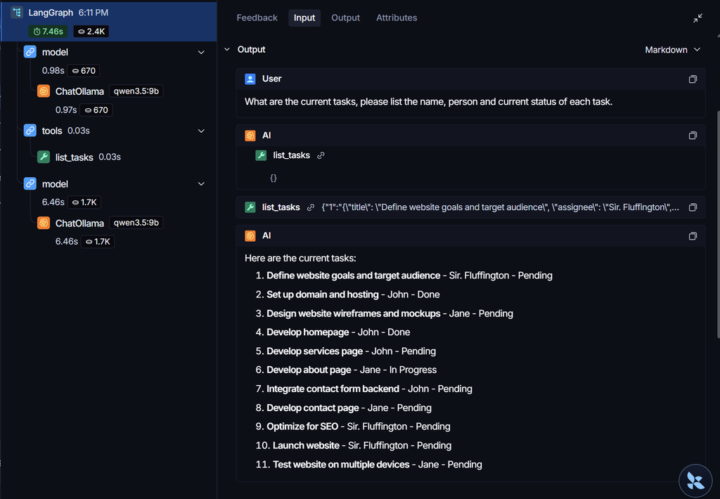

```python
from PIL import Image
im = Image.open("/home/azureuser/localfiles/jonas_g/NLP4/EX08/trace.png")
im
```

## Exercise 3 AI assistant for IT services at Hagenberg campus

The university provides IT services required by students and employees alike. Information about these services is collected in an e-learning course and provided as a set of PDF documents. Finding relevant information in these documents can be quite cumbersome. You are therefore tasked with creating an LLM-powered assistant that answers questions about university IT services. Because this information changes frequently, fine-tuning a language model is not a sustainable option. Instead, you will build a Retrieval-Augmented Generation (RAG) system that enables an LLM to answer questions based on the provided PDF documents. An entrypoint to RAG with LangChain can be found here.

**Tasks:**

1. Load and process the provided PDF files containing IT service information using LangChain.
2. Split the documents into suitable text chunks and generate embeddings for them.
3. Store the embeddings in a vector database that supports similarity search.
4. Implement a retrieval pipeline that selects relevant document chunks for a given user query.
5. Integrate a large language model via LangChain to generate answers grounded in the retrieved documents.
6. Demonstrate that the assistant answers questions based on the document content rather than relying on prior model knowledge.

**Deliverables:** A notebook that demonstrates the RAG pipeline, including PDF ingestion, vector store creation, retrieval, and question answering. The notebook should contain example queries with generated answers and a short discussion of the benefits and limitations of using RAG for this use case.

**Short discussion**

- Benefits:
  - whenever a document changes we only need to change its entry in the vecotr DB instead of having to retrain the entire model again
  - it reduces the halucinations of the system
  - it can give sources to where it find them (if we pass the entire source path like a website it can even link to it), with the chain implimentation we can even record the source docs of the found document and present them to user straight up
- limitations:
  - Altough it reduces halucinations it does not eliminate them entirely (can make them even more insidius by getting 90% right and halucinating just a few parts, in a installation step for example)
  - might make the user trust the system too much and not use the sources
  - The search is still limited as the model can't come through truly ALL parts oft the vector DB
  - The chunking of documents can split them up and cause the search to come upon a heading of the topic we are searching for and the text under the heading in a different lost chunk
  - more tokens are used (all the docs that are loaded are read, every question again, an agent requires even more)

**Explenation on path**

There are two ways to RAG either with fixed retrieval or an Agent, as this exercise is about retrieval I decided to use it over using a fickle agent with a tool.

```python
from pathlib import Path
from typing_extensions import TypedDict
from IPython.display import Image, display

from langgraph.graph import StateGraph, START, END

from langchain.messages import SystemMessage
from langchain.tools import tool

from langchain_ollama import ChatOllama, OllamaEmbeddings
from langchain_community.document_loaders import PDFMinerLoader#, PDFMinerPDFasHTMLLoader
from langchain_text_splitters import RecursiveCharacterTextSplitter
from langchain_core.vectorstores import InMemoryVectorStore
from langchain_core.documents.base import Document
```

**AI function**

prompt: "<my loader> how can i modify the content of the pdfs to remove useless signs and new lines? "

```python
import re
def clean_text(text: str):
    # Replace multiple newlines/tabs with a single space

    text = "\n".join([line for line in text.splitlines() if "Page |" not in line])

    text = re.sub(r'[\r\n\t]+', ' ', text)
    # Remove non-printable or "useless" special signs (optional)
    # This keeps alphanumeric and standard punctuation
    text = re.sub(r'[^\x00-\x7F]+', '', text)
    # Collapse multiple spaces into one
    text = re.sub(r'\s+', ' ', text)
    return text.strip()
```

```python
paths = Path("/home/azureuser/localfiles/jonas_g/NLP4/EX08/it_hgb_docs")
docs = [PDFMinerLoader(file) for file in paths.iterdir()]
docs = [item for sublist in docs for item in sublist.load()]
for doc in docs:
    doc.page_content = clean_text(doc.page_content)
sources = [f"Source: {doc.metadata['source']}" for doc in docs]
```

```python
text_splitter = RecursiveCharacterTextSplitter(
    chunk_size=512, chunk_overlap=64,
)
doc_splits = text_splitter.split_documents(docs)
```

```python
print(docs[0].page_content.replace("\n\n", "").strip()[:50])
print("-"*100)
print(doc_splits[0].page_content.replace("\n\n", "").strip()[:50])
```

```
a i l o t o F INSTRUCTIONS MICROSOFT AZURE FOR EDU
----------------------------------------------------------------------------------------------------
a i l o t o F INSTRUCTIONS MICROSOFT AZURE FOR EDU
```

```python
embeddings = OllamaEmbeddings(
    model="qwen3-embedding:8b",
)
```

```python
embeddings.embed_query("hi")[:5]
```

```
[0.024280787, 0.013711244, -0.010559903, -0.034268647, 0.008835684]
```

```python
vectorstore = InMemoryVectorStore(embeddings)
vectorstore.add_documents(
    documents=doc_splits
)
retriever = vectorstore.as_retriever(search_type="mmr", search_kwargs={"k": 5, "fetch_k": 50}) # search for 50 return top 5
```

```python
result = retriever.invoke("Wie can ich drucken?")
print(result)
for i, doc in enumerate(result):
    print(f"{'='*20} Doc {i} {'='*20}")
    print(doc.page_content)
```

```
[Document(id='b080ceb4-1512-4781-a518-b40525f226d0', metadata={'producer': 'Microsoft® PowerPoint® für Microsoft 365', 'creator': 'Microsoft® PowerPoint® für Microsoft 365', 'creationdate': '2025-07-15T07:43:34+02:00', 'title': 'FHOOE-Schulpraesentation 2309', 'author': 'Tanja Zadnik - copylot.at', …
==================== Doc 0 ====================
from an exam (up to 3 days before the exam date) Read PIN for printer (My Profile PIN Code) Login with username@fhooe.at (e.g. s1234567890@fhooe.at) and password University of Applied Sciences Upper Austria 13 Print and Copy Overview of all printers: https://elearning.fh-ooe.at/course/view.php?id=89…
==================== Doc 1 ====================
Seite | 12 Quick Guide - Print and Scan via USB-Stick The scanned document has now been saved to your USB stick. Remove the USB stick as explained in section 4 How to properly remove the USB flash drive? Seite | 13
==================== Doc 2 ====================
can start working. Important: A small window -> Sharing opens automatically. Please confirm with Allow.
==================== Doc 3 ====================
7 2.4 Install drivers ....................................................................................................... 8 2.5 Configure the printer ............................................................................................ 9 3. MAC ............................................…
==================== Doc 4 ====================
will be redirected to your dashboard where all the certificates you have requested will be displayed. To issue a new certificate, please select "Email" from the side menu. In the next step, you can select the desired certificate. Please select the first option "Email-only" and press "Next". Seite 4 …
```

```python
class State(TypedDict):
    prompt: str
    key_words: str
    rewriten: str
    docs: list[Document]
    sources: list[str]
    answer: str
```

```python
llm = ChatOllama(
    model="qwen3.5:9b",
    temperature=0.0,
    streaming=False,
    verbose=True,
    reasoning=False, # could reason for extra performance
    num_ctx = 8192 # does actually change it
    # num_predict=1024
)
extractor = ChatOllama(
    model="qwen3.5:9b",
    temperature=0.0,
    streaming=False,
    verbose=False,
    reasoning=False,
    num_ctx = 128, # does actually change it
    num_predict=16
)
```

```python
EXTRACT_PROMPT = (
    "Look at the input and try to reason about the underlying semantic intent / meaning.\n"
    "Answer only with the keywords question and nothing else."
    "Example:"
    "Question - How can I print?"
    "Keywords - drucker drucken"
    "Here is the initial question:"
    "\n ------- \n"
    "{question}"
    "\n ------- \n"
    "Respond with a collection of keywords translated to german which best encapsulate the prompt:"
)

REWRITE_PROMPT = (
    "Look at the input and try to reason about the underlying semantic intent / meaning.\n"
    "Answer only with the improved question and nothing else."
    "Example:"
    "Question - How can i print?"
    "Answer - Wie kann ich drucken?"
    "Here is the initial question:"
    "\n ------- \n"
    "{question}"
    "\n ------- \n"
    "Formulate an improved question and translate it to german:"
)

GENERATE_PROMPT = (
    "You are an assistant for question-answering tasks. "
    "Use the following pieces of retrieved context to answer the question. "
    "If you don't know the answer, just say that you don't know. "
    "When answering the question also include the sources of where you found the answers"
    "as well as small snippets of the paragraph containing the answer."
    "Example: "
    "Query - How do I log in?"
    "Answer - Through the webpage...."
    "Sources - logging_in.pdf"
    "Keep the answer concise.\n"
    "Question: {question} \n"
    "Alternative Question format: {altquestion}"
    "Context: {context}"
)
```

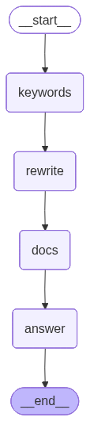

```python
def extract_key_words(state: State):
    answer = extractor.invoke(
        [SystemMessage(content=EXTRACT_PROMPT.format(question=state["prompt"]))]
    )
    return {"key_words":answer.content}

def rewrite_prompt(state: State):
    answer = llm.invoke(
        [SystemMessage(content=REWRITE_PROMPT.format(question=state["prompt"]))]
    )
    return {"rewriten":answer.content}

def get_best_docs(state: State):
    docs: list[Document] = []
    tmp_docs:list[Document]= []
    for query in [state["prompt"], state["rewriten"], state["key_words"]]:
        tmp_docs.extend(retriever.invoke(query))
    sources = set()
    for doc in tmp_docs:
        if doc.id in sources:
            continue
        docs.append(doc)
        sources.add(doc.id)

    return {"docs": docs}

def generate_answer(state: State):
    docs = [f"SOURCE: {Path(doc.metadata['source']).name}\n{doc.page_content}" for doc in state["docs"]]#type:ignore
    answer = llm.invoke(
        [SystemMessage(content=GENERATE_PROMPT.format(question=state["prompt"], altquestion=state["rewriten"], context=docs))]
    )
    return {"answer": answer.content}

graph = StateGraph(State)
graph.add_node("keywords", extract_key_words)
graph.add_node("rewrite", rewrite_prompt)
graph.add_node("docs", get_best_docs)
graph.add_node("answer", generate_answer)

graph.add_edge(START, "keywords")
graph.add_edge("keywords", "rewrite")
graph.add_edge("rewrite", "docs")
graph.add_edge("docs", "answer")
graph.add_edge("answer", END)

chain = graph.compile()

display(Image(chain.get_graph().draw_mermaid_png()))
```

```python
answer = chain.invoke({"prompt": "How can i print?"})
```

```python
print(answer["answer"].replace(". ", ".\n"))
```

```
To print, you can use several methods depending on your needs:

1.
**Via Email**: Send an email with an attachment (e.g., .pdf, .pptx, .xlsx, .docx) to the printer using your FH email address.
The printer will print the document automatically.
2.
**Via USB Stick**: Save your document to a USB stick, insert it into the printer, and follow the on-screen instructions to print.
3.
**Online Printer Portal**: Visit the printer overview page at [https://elearning.fh-ooe.at/course/view.php?id=89](https://elearning.fh-ooe.at/course/view.php?id=89) to manage print jobs or add credit.

You can also set up a printing queue on your device by adding the printer in your system settings (Windows or macOS).

**Sources:**
- *Print via E-Mail.pdf*: Describes printing via email with supported file formats.
- *Print and scan via USB-Stick.pdf*: Explains how to print using a USB stick.
- *IT-Information Semesterstart 2025_EN.pdf*: Provides links to printer management and credit top-up.
```

```python
for doc in answer["docs"]:
    print(doc.metadata["source"])
```

```
/home/azureuser/localfiles/jonas_g/NLP4/EX08/it_hgb_docs/IT-Information Semesterstart 2025_EN.pdf
/home/azureuser/localfiles/jonas_g/NLP4/EX08/it_hgb_docs/Print and scan via USB-Stick.pdf
/home/azureuser/localfiles/jonas_g/NLP4/EX08/it_hgb_docs/Instructions AppsAnywhere.pdf
/home/azureuser/localfiles/jonas_g/NLP4/EX08/it_hgb_docs/Set up printing queue.pdf
/home/azureuser/localfiles/jonas_g/NLP4/EX08/it_hgb_docs/QuickGuide_Harica_Mail_Certificate_en_V1.pdf
/home/azureuser/localfiles/jonas_g/NLP4/EX08/it_hgb_docs/Print via E-Mail.pdf
/home/azureuser/localfiles/jonas_g/NLP4/EX08/it_hgb_docs/Set up printing queue.pdf
/home/azureuser/localfiles/jonas_g/NLP4/EX08/it_hgb_docs/Print via E-Mail.pdf
```

```python
answer = chain.invoke({"prompt": "How can I install mathworks tah?"})
print(answer["answer"].replace(". ", ".\n"))
```

```
To install MathWorks MATLAB (referred to as "Mathworks TAH" in the context), you can follow these steps based on the provided documents:

1.
 **Download the Installer:**
    *   **Inside the FH OÖE network:** Go to the specific network paths (e.g., `\\fhstrfilel1.fhooe.at\lehre$\software\Matlab` for Linz or `S:\Software\Matlab` for Steyr) and download the ISO-file to a USB stick.
    *   **Outside the network:** Visit the official MathWorks website at `https://de.mathworks.com/downloads/web_downloads`, click "Download for current release," choose your platform (Windows or Mac), and download the setup file (e.g., `matlab_<release>_win64.exe`).

2.
 **Install and Activate:**
    *   Locate the downloaded setup file in your downloads directory.
    *   Run the installer (double-click on Windows).
    *   Log in to your existing MathWorks account to activate the license.

**Sources:**
*   `Matlab-TAH_FHOOE_EN.pdf`: "Installation inside the FH OOe network", "Installation outside the FH O network", "Run Setup: Windows: DoubleClick the..."
*   Snippet: "Go to Wels: Linz: Hagenberg: \\\\fshome.hagenberg.fhooe.at\\exchange\\software\\Matlab ...
and download the ISO-file in the needed version via USB Stick to your computer."
*   Snippet: "now or go to https://de.mathworks.com/downloads/web_downloads 6.
Click on button download for current release."
```

```python
answer = chain.invoke({"prompt": "How can I rent equipment?"})
print(answer["answer"].replace(". ", ".\n"))
```

```
To rent equipment, you must make reservations **personally** at the Equipment Rental office; emails cannot be accepted.
Before visiting, you should list the specific equipment you need and consider all signal paths.

**Sources:**
*   **Overview Equipment rental Hagenberg EN.pdf**
    *   *Snippet:* "Reservations MUST be done PERSONALLY at the rental! Mails cannot be accepted."
    *   *Snippet:* "Think about which equipment you will need in detail and write it down before you come to Equipment rental."
```

```python
answer = chain.invoke({"prompt": "How can cook shwoblydobbly?"})
print(answer["answer"].replace(". ", ".\n"))
```

```
I don't know how to cook "shwoblydobbly" because this term does not appear in the provided context, and it is likely a made-up word or a misspelling.
The retrieved documents contain instructions for creating accounts, using USB sticks, setting up MFA, and renting equipment, but no cooking recipes or instructions.
```